# prophet and NNS.ARMA comparison

Fred Viole

November 1, 2017

## Required Packages

These examples were performed using `NNS 3.7`, currently only available on CRAN.

```r
require(NNS);require(prophet);require(dplyr);require(datasets);require(quantmod)
```

## Retail Sales Example

Below is the retail sales data incorporated with the Facebook prophet repository.

```r
retail<-read.csv("https://raw.githubusercontent.com/facebookincubator/prophet/master/examples/example_retail_sales.csv",header=T,sep = ",")
```

We are forecasting the last 50 periods…

```r
l=length(retail[,1])-50
```

### `prophet` model:

Here is the code for the `prophet` model:

```r
m <- prophet(retail[1:l,])
```

```
## Initial log joint probability = -2.42146
## Optimization terminated normally:
##   Convergence detected: relative gradient magnitude is below tolerance
```

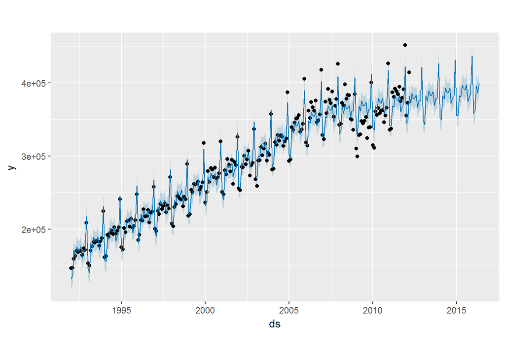

```r
future <- make_future_dataframe(m,periods=50,freq = 'm')
retail_fcst <- predict(m, future)
plot(m,retail_fcst)
```

### `NNS` model:

Here is the code for the `NNS` model:

```r
nns.retail.fcst<- NNS.ARMA(retail[,2],h=50,seasonal.factor = 12,method = 'lin',training.set = l)
```

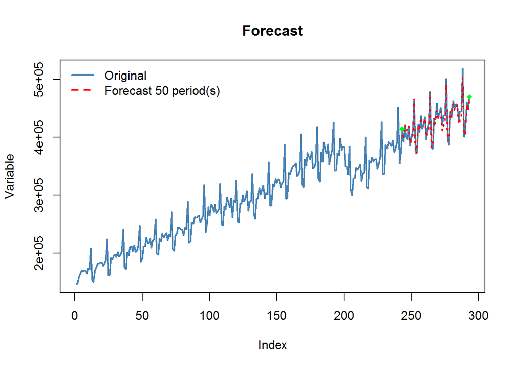

### `prophet` MSE:

```r
mean((tail(retail_fcst$yhat,50)-tail(retail[,2],50))^2)
```

```
## [1] 2392859440
```

### `NNS` MSE:

```r
mean((nns.retail.fcst-tail(retail[,2],50))^2)
```

```
## [1] 52793721
```

# SCORE `NNS`: 1 `prophet`: 0

## Peyton Manning Example (Raw Values):

Next is the raw Peyton Manning example from the Facebook `prophet` repository.

```r
omaha<- read.csv("https://raw.githubusercontent.com/facebookincubator/prophet/master/examples/example_wp_peyton_manning.csv")
```

We are forecasting the last 365 periods…

```r
l=length(omaha[,1])-365
```

### `prophet` model:

```r
m <- prophet(omaha[1:l,])
```

```
## Initial log joint probability = -4.0564
## Optimization terminated normally:
##   Convergence detected: relative gradient magnitude is below tolerance
```

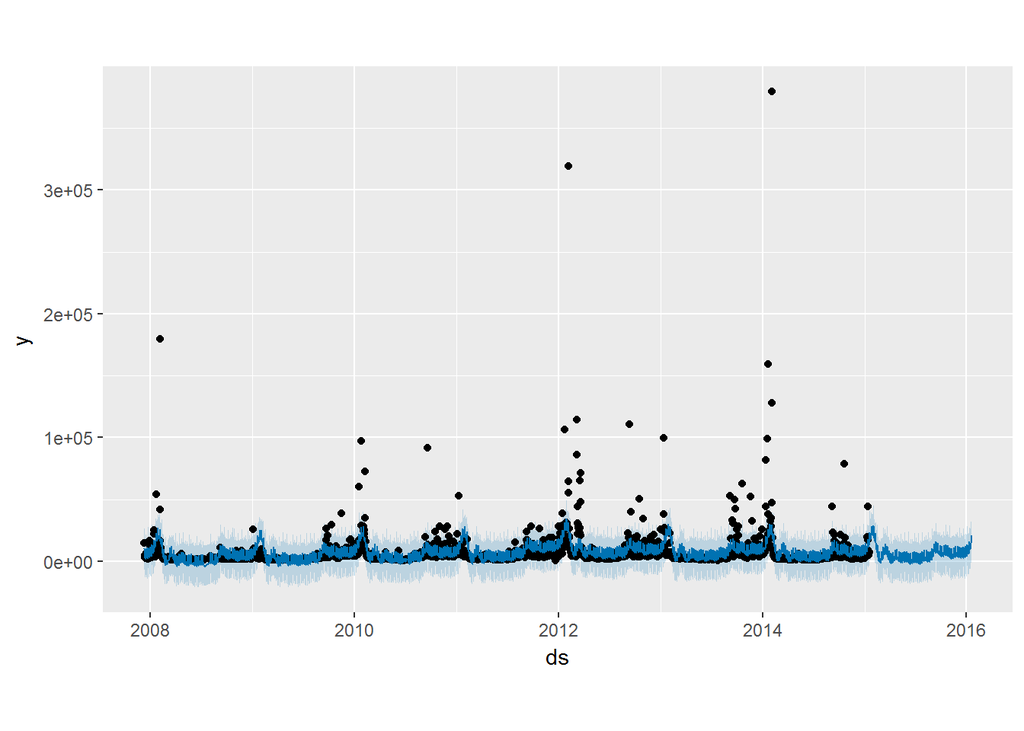

```r
future <- make_future_dataframe(m,periods=365)
omaha_fcst <- predict(m, future)
plot(m,omaha_fcst)
```

### `NNS` model:

`NNS` is using a `seasonal.factor=c(1,sf)` which translates to a daily and best reported lag from our seasonality test. This is not optimized.

```r
a=NNS.seas(omaha[,2],plot=F)
test=t(sapply(a$all.periods$Period, function(i)
  c(i,mean((NNS.ARMA(omaha[,2],h=365,training.set=l,
  seasonal.factor=i,plot=F,method='lin')-tail(omaha[,2],365))^2))))

colnames(test)=c("Period","MSE")

sf<- test[which.min(test[,2]),1]
sf
```

```
## Period
##    331
```

```r
nns.omaha.fcst<- NNS.ARMA(omaha[,2],h=365,seasonal.factor = c(1,sf),method = 'lin',training.set = l)
```

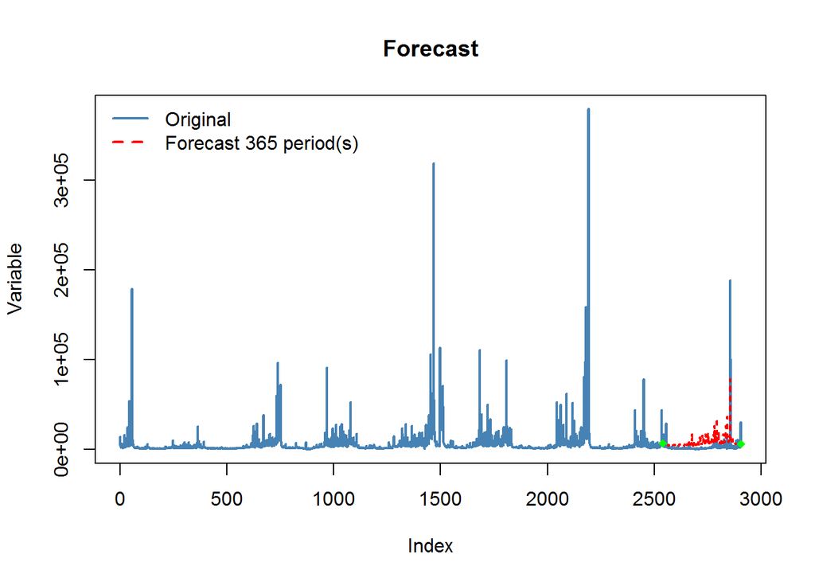

### `prophet` MSE:

```r
mean((tail(omaha_fcst$yhat,365)-tail(omaha[,2],365))^2)
```

```
## [1] 150018073
```

### `NNS` MSE:

```r
mean((nns.omaha.fcst-tail(omaha[,2],365))^2)
```

```
## [1] 101266229
```

# SCORE `NNS`: 2 `prophet`: 0

## Peyton Manning Example (log values):

Using the log values of the preceding Peyton Manning dataset.

```r
log_omaha<- read.csv("https://raw.githubusercontent.com/facebookincubator/prophet/master/examples/example_wp_peyton_manning.csv") %>% mutate(y = log(y))
```

Again, we are forecasting the last 365 periods…

```r
l=length(log_omaha[,1])-365
```

### `prophet` model:

```r
m <- prophet(log_omaha[1:l,])
```

```
## Initial log joint probability = -16.5944
## Optimization terminated normally:
##   Convergence detected: relative gradient magnitude is below tolerance
```

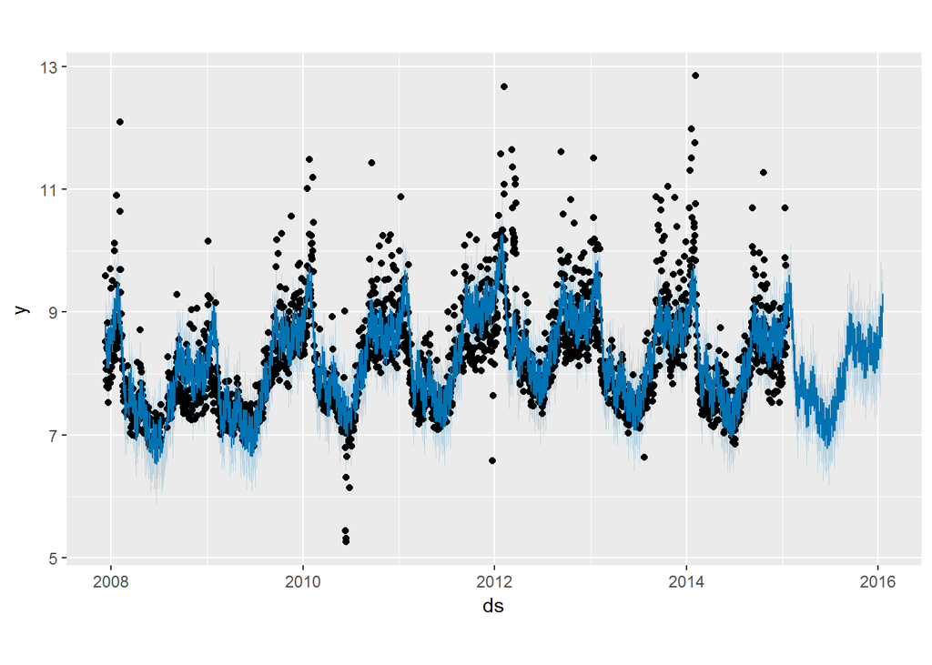

```r
future <- make_future_dataframe(m,periods=365)
log_omaha_fcst <- predict(m, future)
plot(m,log_omaha_fcst)
```

### `NNS` model:

`NNS` is using a `seasonal.factor=c(1,sf)` which translates to a daily and best reported lag from our seasonality test. This is not optimized.

```r
a=NNS.seas(log_omaha[,2],plot=F)
test=t(sapply(a$all.periods$Period, function(i)
  c(i,mean((NNS.ARMA(log_omaha[,2],h=365,training.set=l,
  seasonal.factor=i,plot=F,method='lin')-tail(log_omaha[,2],365))^2))))

colnames(test)=c("Period","MSE")

sf<- test[which.min(test[,2]),1]
sf
```

```
## Period
##    362
```

```r
nns.log.omaha.fcst<- NNS.ARMA(log_omaha[,2],h=365,seasonal.factor = c(1,sf),method = 'nonlin',training.set = l)
```

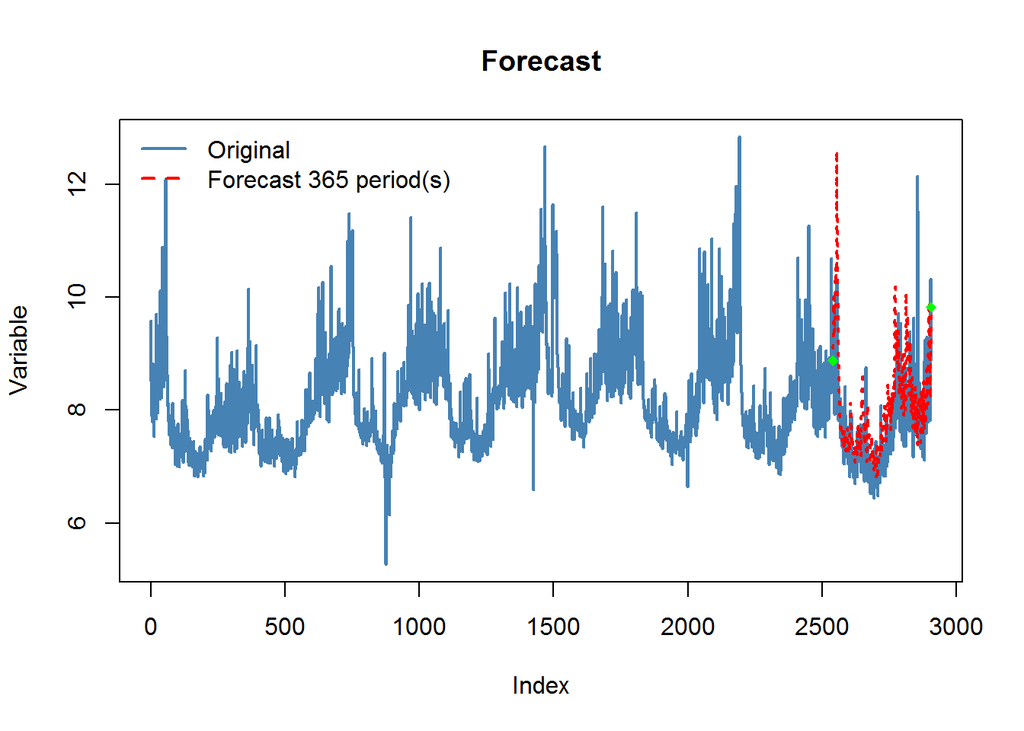

### `prophet` MSE:

```r
mean((tail(log_omaha_fcst$yhat,365)-tail(log_omaha[,2],365))^2)
```

```
## [1] 0.3617284
```

### `NNS` MSE:

```r
mean((nns.log.omaha.fcst-tail(log_omaha[,2],365))^2)
```

```
## [1] 0.6019713
```

# SCORE `NNS`: 2 `prophet`: 1

## Notes

This dataset presents more questions than it answers. Specifically:

```r
mean((exp(1)^tail(log_omaha_fcst$yhat,365)-tail(omaha[,2],365))^2)
```

```
## [1] 127292436
```

- Can we recover better log estimates from translated raw estimates for NNS? No.

```r
mean((log(nns.omaha.fcst)-tail(log_omaha[,2],365))^2)
```

```
## [1] 1.871977
```

# `lynx` dataset

Next we test the Canadian lynx dataset suggested from Andrew Gelman’s blog post on prophet: http://andrewgelman.com/2017/03/01/facebooks-prophet-uses-stan/

```r
data(lynx)
l=length(lynx)-34
```

### `prophet` model and RMSE:

```r
m <- prophet(data.frame(ds=1:80,y=lynx[1:80]))
```

```
## Initial log joint probability = -4.87324
## Optimization terminated normally:
##   Convergence detected: absolute parameter change was below tolerance
```

```r
future <- make_future_dataframe(m,periods=35)
fcast <- predict(m,future)
sqrt(mean((lynx[-(1:80)]-fcast[-(1:80),"yhat"])^2))
```

```
## [1] 1823.442
```

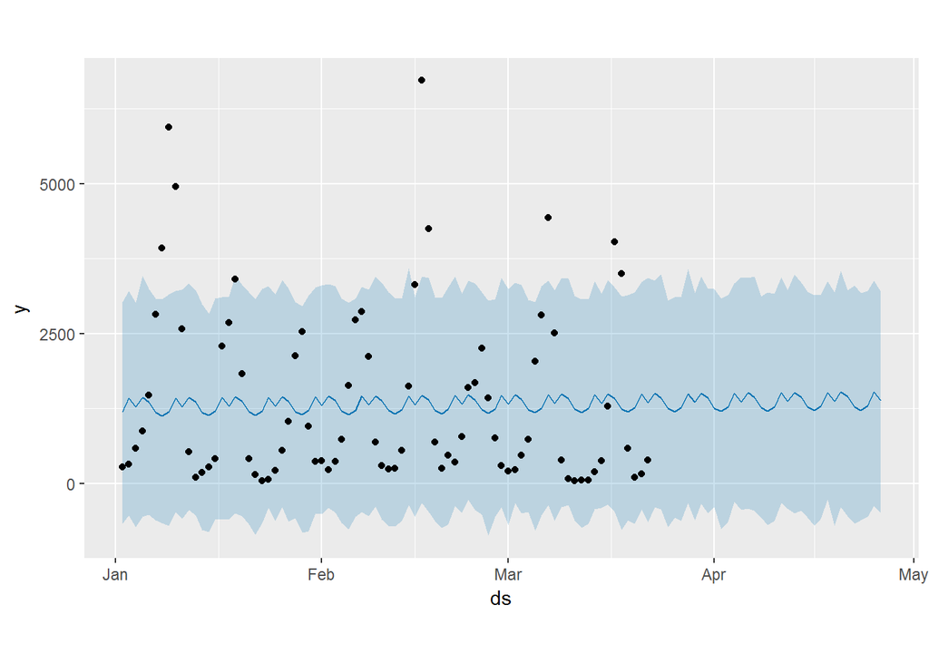

```r
plot(m,fcast)
```

### `NNS` model and RMSE:

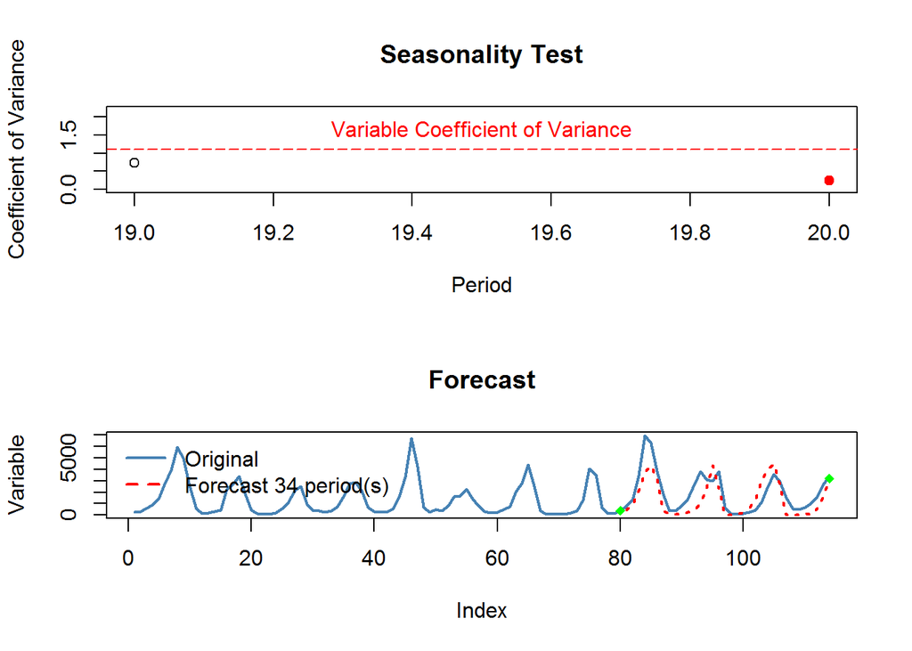

```
## [1] 1252.73
```

```r
sqrt(mean((NNS.ARMA(lynx,h=34,training.set = 80,method='lin',seasonal.factor=F,best.periods=2)-tail(lynx,34))^2))
```

# SCORE `NNS`: 3 `prophet`: 1

# S&P 500

Finally we are going to forecast 252 S&P 500 adjusted closing prices. We retrieve the data via `quantmod` commands:

```r
getSymbols("SPY",src='yahoo')
```

```
## [1] "SPY"
```

```r
SPY=as.numeric(Ad(SPY))
```

### `prophet` model:

```r
l=length(SPY)-252
oos = tail(SPY,252)

m <- prophet(data.frame(ds=1:l,y=SPY[1:l]))
```

```
## Initial log joint probability = -33.9079
## Optimization terminated normally:
##   Convergence detected: relative gradient magnitude is below tolerance
```

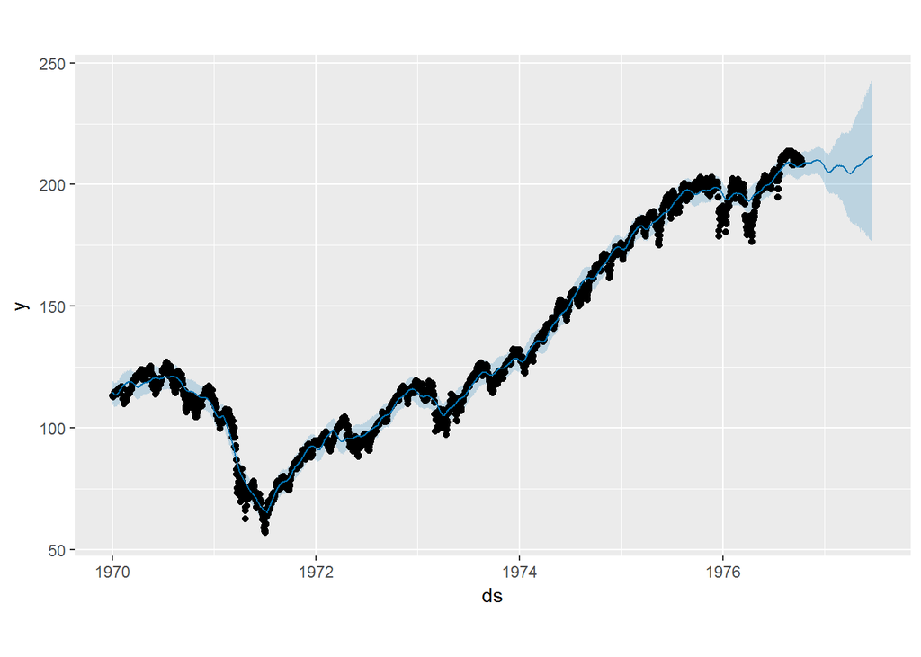

```r
future <- make_future_dataframe(m,periods=252)
SPY_fcst <- predict(m, future)
plot(m,SPY_fcst)
```

### `prophet` RMSE:

```r
sqrt(mean((oos-tail(SPY_fcst$yhat,252))^2))
```

```
## [1] 30.20166
```

## Linear Regression

We present the linear regression just for a visualization, as its residuals clearly do not deserve consideration.

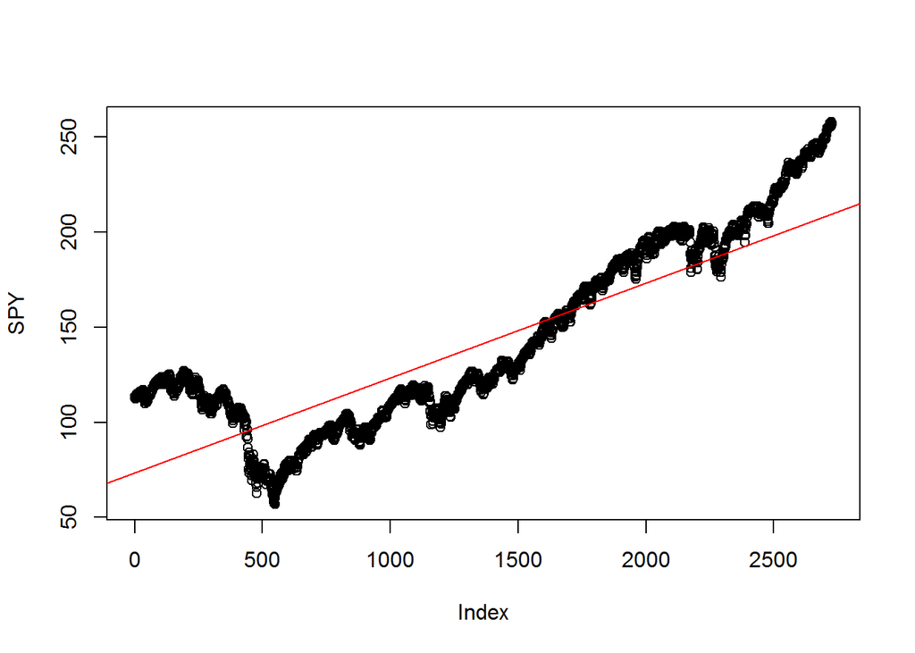

```r
plot(SPY)
abline(lm(SPY[1:l]~c(1:l)),col='red')
```

### `NNS` model and RMSE:

`NNS` is using a `seasonal.factor=c(1,5,21,63,126,252)` which translates to a daily, weekly, monthly and quarterly, bi-annual and annual lag for S&P closing prices.

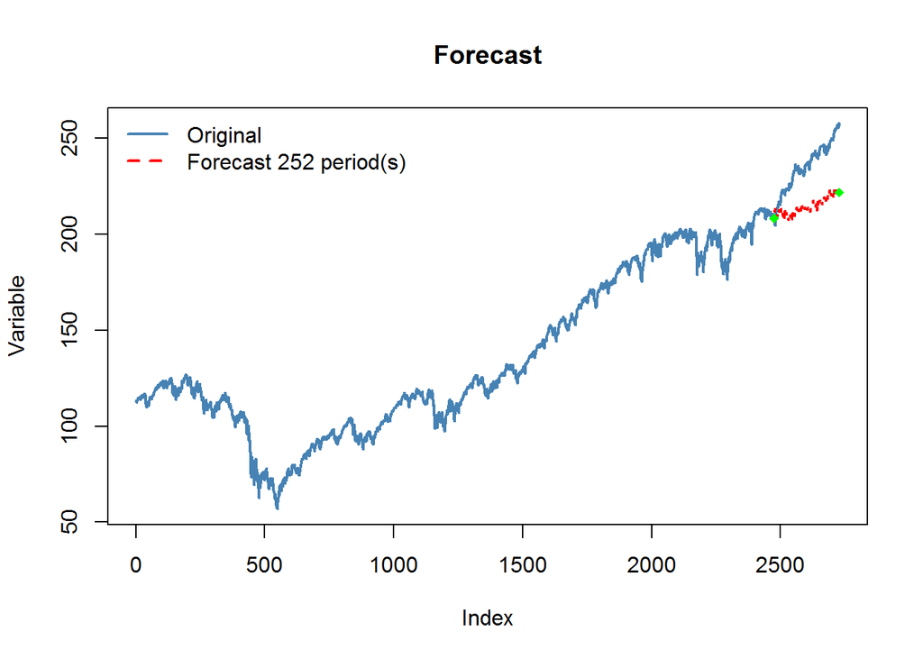

```r
nns.sp = NNS.ARMA(SPY,h=252,seasonal.plot = F,seasonal.factor =c(1,5,21,63,126,252), training.set = l,method = 'nonlin')
```

```r
sqrt(mean((oos-nns.sp)^2))
```

```
## [1] 22.7117
```

# SCORE `NNS`: 4 `prophet`: 1

# S&P500 - Year 2

So far so good…let’s try a different year:

### `prophet` model and RMSE:

```r
l=length(SPY)-252*2
oos = tail(SPY[1:l],252)

m <- prophet(data.frame(ds=1:l,y=SPY[1:l]))
```

```
## Initial log joint probability = -37.7735
## Optimization terminated normally:
##   Convergence detected: relative gradient magnitude is below tolerance
```

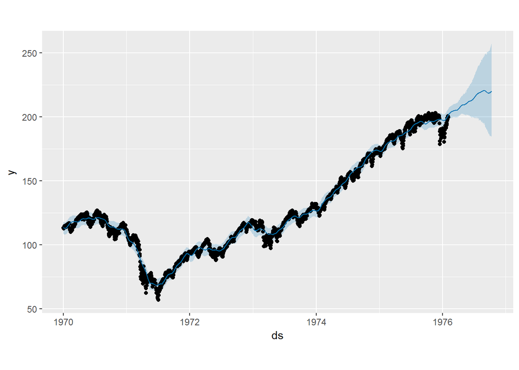

```r
future <- make_future_dataframe(m,periods=252)
SPY_fcst <- predict(m, future)
plot(m,SPY_fcst)
```

```r
sqrt(mean((oos-tail(SPY_fcst$yhat,252))^2))
```

```
## [1] 18.51615
```

### `NNS` model and RMSE:

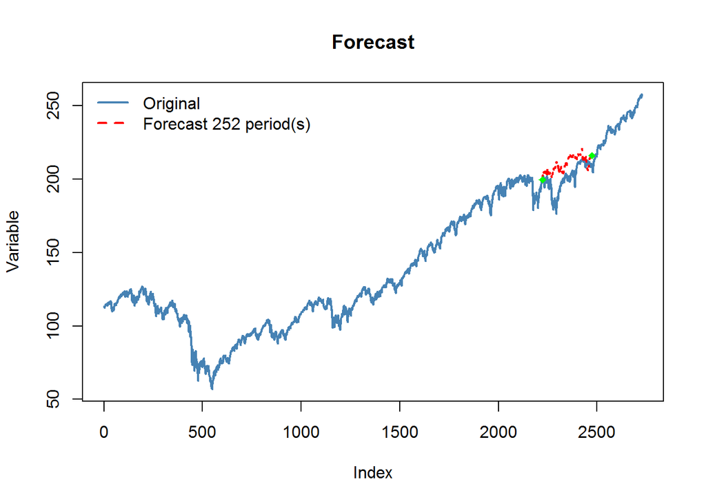

```r
nns.sp = NNS.ARMA(SPY,h=252,seasonal.plot = F,seasonal.factor =c(1,5,21,63,126,252), training.set = l,method = 'nonlin')
```

```r
sqrt(mean((oos-nns.sp)^2))
```

```
## [1] 16.00169
```

# SCORE `NNS`: 5 `prophet`: 1

# S&P500 - Year 3

So far so good (again)…let’s try a different year:

### `prophet` model and RMSE:

```r
l=length(SPY)-252*3
oos = tail(SPY[1:l],252)

m <- prophet(data.frame(ds=1:l,y=SPY[1:l]))
```

```
## Initial log joint probability = -41.1845
## Optimization terminated normally:
##   Convergence detected: relative gradient magnitude is below tolerance
```

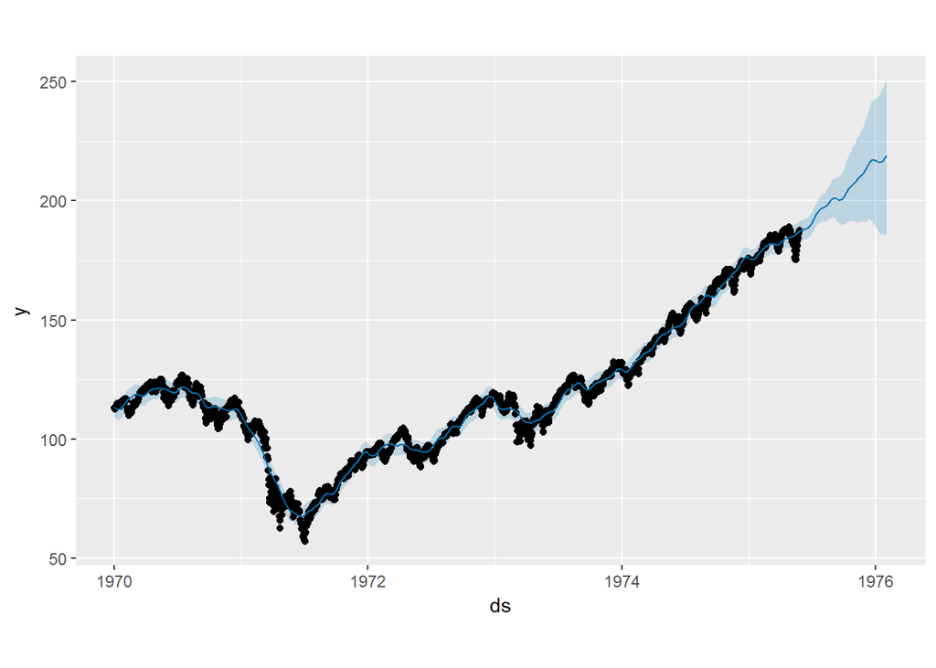

```r
future <- make_future_dataframe(m,periods=252)
SPY_fcst <- predict(m, future)
plot(m,SPY_fcst)
```

```r
sqrt(mean((oos-tail(SPY_fcst$yhat,252))^2))
```

```
## [1] 27.84086
```

### `NNS` model and RMSE:

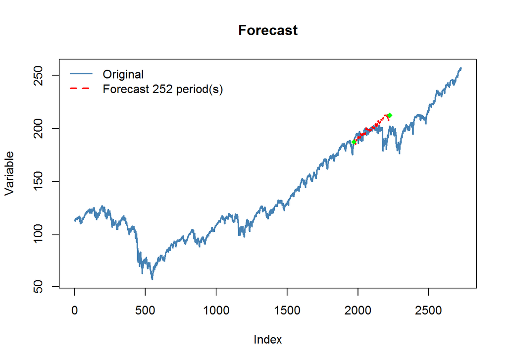

```r
nns.sp = NNS.ARMA(SPY,h=252,seasonal.plot = F,seasonal.factor =c(1,5,21,63,126,252), training.set = l,method = 'nonlin')
```

```r
sqrt(mean((oos-nns.sp)^2))
```

```
## [1] 24.72559
```

# SCORE `NNS`: 6 `prophet`: 1

# Summary

To summarize, `NNS` was more accurate (often by substantial amounts) out of sample for all but the log transformed Peyton Manning dataset. However, `prophet` was exceptionally faster in its runtimes.

To be fair, `prophet` was not altered from its default settings and any interested readers are more than welcome to suggest different settings to improve performance. `NNS` could also improve performance as it was not optimized either.

Comments welcome at: ovvo.financial.systems@gmail.com

Further `NNS.ARMA` examples are available at: https://github.com/OVVO-Financial/NNS/blob/NNS-Beta-Version/examples/NNS%20ARMA.pdf

Thank you for your interest!